# Homework 10

Andrei Graham

2026-02-12

## Instructions

Answer the following questions and complete the exercises in RMarkdown. Please embed all of your code and push your final work to your repository. Your final lab report should be organized, clean, and run free from errors. Remember, you must remove the `#` for the included code chunks to run. Be sure to add your name to the author header above.

Make sure to use the formatting conventions of RMarkdown to make your report neat and clean!

## Background

In the `data` folder, you will find data about shark incidents in California between 1950-2022. The [data](https://catalog.data.gov/dataset/shark-incident-database-california-56167) are from: State of California- Shark Incident Database.

## Load the libraries

```r
library("tidyverse")
library("janitor")
```

## Load the data

Run the following code chunk to import the data. In this chunk, I am removing NA’s.

```r
sharks <-
  read_csv("data/SharkIncidents_1950_2022_220302.csv",
           na=c("NA", "N/A", "Unknown", "NOT COUNTED", "", " ")) %>%
  clean_names()
```

## Questions

1. Are there any “hotspots” for shark incidents in California? Show the top five counties with the most incidents.

```r
sharks%>%
  group_by(county)%>%
  count(county)%>%
  arrange(desc(n))
```

```
## # A tibble: 22 × 2
## # Groups:   county [22]
##    county              n
##    <chr>           <int>
##  1 San Diego          25
##  2 Humboldt           20
##  3 San Mateo          19
##  4 Santa Barbara      19
##  5 Marin              16
##  6 Monterey           16
##  7 Santa Cruz         15
##  8 Sonoma             15
##  9 San Luis Obispo    14
## 10 Los Angeles        10
## # ℹ 12 more rows
```

```r
#San Diego, Humboldt, Santa Barbara, San Mateo, Monterey
```

2. Make a plot that shows the total number of incidents per county.

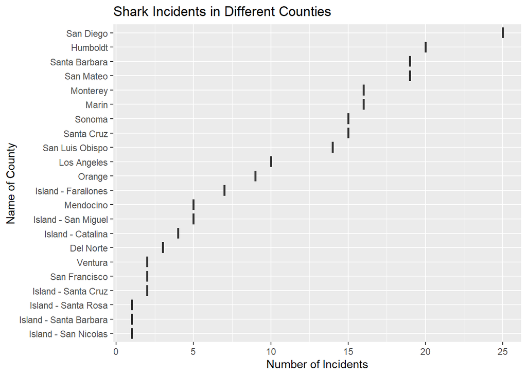

```r
#geom_col won't run on my home computer (for some reason?), but it works in class so I added geom_boxplot so I can see the plot
sharks%>%
  group_by(county)%>%
  count(county)%>%
  arrange(desc(n))%>%
  ggplot(aes(x=reorder(county,n), y=n))+
    geom_boxplot()+
    #geom_col()+
    coord_flip()+
    labs(title= "Shark Incidents in Different Counties",
       y= "Number of Incidents",
       x= "Name of County")
```

3. Are there months of the year when incidents are more likely to occur? Make a plot that shows the total number of incidents by month. Which month has the highest number of incidents?

```r
sharks%>%
  count(month, name = "total_incidents")%>%
  arrange(desc(total_incidents))
```

```
## # A tibble: 12 × 2
##    month total_incidents
##    <dbl>           <int>
##  1    10              36
##  2     9              34
##  3     8              31
##  4     7              27
##  5     5              16
##  6    11              16
##  7     6              14
##  8    12              13
##  9     1               8
## 10     4               7
## 11     3               5
## 12     2               4
```

```r
#sharks%>%
 # count(month, name = "total_incidents")%>%
 # ggplot(aes(x=month, y=total_incidents))+
 # geom_col()+
 # labs(title = "shark incidents by month",
     #  x= "month",
     #  y= "number of incidents")


#my code won't run and chatgpt says its because my rlang is outdated 1.1.6 instead of 1.1.7, but I cant install the package :(
```

[figure not shown]

```r
sharks%>%
  count(month, name = "total_incidents")%>%
  mutate(month = factor(month))%>%
  ggplot(aes(x=month, y=total_incidents))#+
```

```r
  #geom_col()
```

```r
sharks%>%
  count(month, name = "total_incidents")%>%
  arrange(desc(total_incidents))
```

```
## # A tibble: 12 × 2
##    month total_incidents
##    <dbl>           <int>
##  1    10              36
##  2     9              34
##  3     8              31
##  4     7              27
##  5     5              16
##  6    11              16
##  7     6              14
##  8    12              13
##  9     1               8
## 10     4               7
## 11     3               5
## 12     2               4
```

```r
#July, August, September and October are when the attacks are most likely to occur
```

4. Is there a time of day when most attacks occur? Make a plot that shows the total number of incidents by time of day. Which time of day has the highest number of incidents?

```r
#sharks%>%
  #group_by(time)%>%
  #count(time, name = "total_incidents")%>%
  #ggplot(aes(x=reorder(time, total_incidents),  y=total_incidents))+
  #geom_col()+
  #coord_flip()+
  #labs(title = "total shark incidents by time",
       #x= "time of day",
       #y= "number of incidents")
```

5. How do the number and types of injuries compare by county? Make a table that shows the number of injury types by county. Which county has the highest number incidents? (hint: your table should be in wide format)

```r
sharks%>%
  count(county, injury, name = "n_incidents")%>%
  pivot_wider(names_from = injury,
              values_from = n_incidents
              )
```

```
## # A tibble: 22 × 8
##    county                 minor  none major `minor*` `none*` fatal `major*`
##    <chr>                  <int> <int> <int>    <int>   <int> <int>    <int>
##  1 Del Norte                  2     1    NA       NA      NA    NA       NA
##  2 Humboldt                   2     9     7        1       1    NA       NA
##  3 Island - Catalina          1     3    NA       NA      NA    NA       NA
##  4 Island - Farallones       NA    NA     7       NA      NA    NA       NA
##  5 Island - San Miguel        2    NA     2       NA      NA     1       NA
##  6 Island - San Nicolas       1    NA    NA       NA      NA    NA       NA
##  7 Island - Santa Barbara    NA    NA    NA       NA      NA    NA        1
##  8 Island - Santa Cruz        1     1    NA       NA      NA    NA       NA
##  9 Island - Santa Rosa       NA    NA     1       NA      NA    NA       NA
## 10 Los Angeles                6     2    NA       NA      NA     1        1
## # ℹ 12 more rows
```

```r
  sharks%>%
    count(county, name="total_incidents")%>%
    arrange(desc(total_incidents))
```

```
## # A tibble: 22 × 2
##    county          total_incidents
##    <chr>                     <int>
##  1 San Diego                    25
##  2 Humboldt                     20
##  3 San Mateo                    19
##  4 Santa Barbara                19
##  5 Marin                        16
##  6 Monterey                     16
##  7 Santa Cruz                   15
##  8 Sonoma                       15
##  9 San Luis Obispo              14
## 10 Los Angeles                  10
## # ℹ 12 more rows
```

```r
  #San Diego has the highest number of incidents
```

6. Use the table from #5 to make a plot that shows the total number of incidents by county.

```r
total_county <- sharks%>%
  count(county, name= "total_incidents")

#total_county%>%
  #ggplot(aes(x=reorder(county, total_incidents), y=total_incidents))+
 # geom_col()+
 # coord_flip()+
 # labs(title = "total shark incidents by county",
      # x= "county",
      # y= "number of incidents")
```

7. In the data, `mode` refers to a type of activity. Which activity is associated with the highest number of incidents?

```r
sharks%>%
  count(mode, name = "total_incidents")%>%
  arrange(desc(total_incidents))
```

```
## # A tibble: 8 × 2
##   mode                total_incidents
##   <chr>                         <int>
## 1 Surfing / Boarding               85
## 2 Freediving                       36
## 3 Kayaking / Canoeing              30
## 4 Swimming                         22
## 5 Scuba Diving                     20
## 6 Hookah Diving                    10
## 7 Paddleboarding                    7
## 8 Walking in shallow                1
```

```r
#Surfing is the activity with the highest number of incidents
```

8. Make a plot that compares the number of incidents by activity.

```r
#sharks%>%
  #count(mode, name = "total_incidents")%>%
  #arrange(desc(total_incidents))%>%
  #ggplot(aes(x=reorder(mode, total_incidents),
             #x=total_incidents))+
  #geom_col()+
  #coord_flip()+
  #labs(title = "shark incidents by activity",
      # x= "activity",
      # y= "number of incidents")
```

9. Which shark species is involved in the highest number of incidents?

```r
sharks%>%
  count(species, name = "shark_species")%>%
  arrange(desc(shark_species))
```

```
## # A tibble: 12 × 2
##    species      shark_species
##    <chr>                <int>
##  1 White                  181
##  2 <NA>                    14
##  3 Hammerhead               3
##  4 Blue                     2
##  5 Killer Whale             2
##  6 Leopard                  2
##  7 Salmon                   2
##  8 Blue*                    1
##  9 Mako                     1
## 10 Sevengill                1
## 11 Thresher                 1
## 12 blue                     1
```

```r
#(Great)White Shark is the species with the highes number of incidents
```

10. Are all incidents involving Great White’s fatal? Make a plot that shows the number and types of incidents for Great White’s only.

```r
#sharks%>%
  #filter(species=="White")%>%
 # count(injury, name = "injury_type")%>%
  #ggplot(aes(x= reorder(injury, injury_type),
             #y= injury_type))+
  #geom_col()+
 # coord_flip()+
 # labs(title= "great white shark incidents",
      # x= "injury type",
      # y= "number of incidents")
```

## Knit and Upload

Please knit your work as an .html file and upload to Canvas. Homework is due before the start of the next lab. No late work is accepted. Make sure to use the formatting conventions of RMarkdown to make your report neat and clean!